# AllLife Bank Customer Segmentation

### Context

AllLife Bank wants to focus on its credit card customer base in the next financial year. They have been advised by their marketing research team, that the penetration in the market can be improved. Based on this input, the Marketing team proposes to run personalized campaigns to target new customers as well as upsell to existing customers. Another insight from the market research was that the customers perceive the support services of the bank poorly. Based on this, the Operations team wants to **upgrade the service delivery model, to ensure that customer queries are resolved faster**. Head of Marketing and Head of Delivery both decide to reach out to the Data Science team for help.

Objectives

- Analyze the customers, their spending patterns and past interaction with the bank
- Employ clustering algorithms
- Identify different segments in the existing customer base
- Optimize the model using appropriate techniques
- Provide recommendations to the bank on how to better market to and service these customers.

### Data Description

The data provided is of various customers of a bank and their financial attributes like credit limit, the total number of credit cards the customer has, and different channels through which customers have contacted the bank for any queries (including visiting the bank, online and through a call center).

- Sl_No: Primary key of the records
- Customer Key: Customer identification number
- Average Credit Limit: Average credit limit of each customer for all credit cards
- Total credit cards: Total number of credit cards possessed by the customer
- Total visits bank: Total number of visits that customer made (yearly) personally to the bank
- Total visits online: Total number of visits or online logins made by the customer (yearly)
- Total calls made: Total number of calls made by the customer to the bank or its customer service department (yearly)

### Importing Libraries

```python
# If not already installed, install them first.

# Libraries to help with reading and manipulating data
import numpy as np
import pandas as pd

# Libraries to help with data visualization
import matplotlib.pyplot as plt
import seaborn as sns

# Removes the limit for the number of displayed columns
pd.set_option("display.max_columns", None)
# Sets the limit for the number of displayed rows
pd.set_option("display.max_rows", 200)

# to scale the data using z-score
from sklearn.preprocessing import StandardScaler

# to compute distances
from scipy.spatial.distance import pdist

# to perform hierarchical clustering, compute cophenetic correlation, and create dendrograms
from sklearn.cluster import AgglomerativeClustering
from scipy.cluster.hierarchy import dendrogram, linkage, cophenet

# to perform PCA
from sklearn.decomposition import PCA

%matplotlib inline

from sklearn.model_selection  import train_test_split
from sklearn.cluster import KMeans

from scipy.stats import zscore
from scipy.spatial.distance import cdist
from yellowbrick.cluster.base import ClusteringScoreVisualizer
from sklearn.metrics import silhouette_score
from yellowbrick.cluster import SilhouetteVisualizer

import copy

# To suppress the warnings
import warnings

warnings.filterwarnings("ignore")

# This will help in making the Python code more structured automatically (good coding practice)
%load_ext nb_black
```

### Loading Data

```python
bank = pd.read_excel("Credit+Card+Customer+Data.xlsx")
```

```python
# Checking the number of rows and columns in the data
print("The dataset has", bank.shape[0], "rows and", bank.shape[1], "columns")
```

```
The dataset has 660 rows and 7 columns
```

### Data Overview

```python
# let's create a copy of the data
df = bank.copy()
```

```python
# let's view the first 5 rows of the data
df.head()
```

|  | Sl_No | Customer Key | Avg_Credit_Limit | Total_Credit_Cards | Total_visits_bank | Total_visits_online | Total_calls_made |
| --- | --- | --- | --- | --- | --- | --- | --- |
| 0 | 1 | 87073 | 100000 | 2 | 1 | 1 | 0 |
| 1 | 2 | 38414 | 50000 | 3 | 0 | 10 | 9 |
| 2 | 3 | 17341 | 50000 | 7 | 1 | 3 | 4 |
| 3 | 4 | 40496 | 30000 | 5 | 1 | 1 | 4 |
| 4 | 5 | 47437 | 100000 | 6 | 0 | 12 | 3 |

```python
# let's view the last 5 rows of the data
df.tail()
```

|  | Sl_No | Customer Key | Avg_Credit_Limit | Total_Credit_Cards | Total_visits_bank | Total_visits_online | Total_calls_made |
| --- | --- | --- | --- | --- | --- | --- | --- |
| 655 | 656 | 51108 | 99000 | 10 | 1 | 10 | 0 |
| 656 | 657 | 60732 | 84000 | 10 | 1 | 13 | 2 |
| 657 | 658 | 53834 | 145000 | 8 | 1 | 9 | 1 |
| 658 | 659 | 80655 | 172000 | 10 | 1 | 15 | 0 |
| 659 | 660 | 80150 | 167000 | 9 | 0 | 12 | 2 |

```python
# viewing a random sample of the dataset
df.sample(n=10, random_state=1)
```

|  | Sl_No | Customer Key | Avg_Credit_Limit | Total_Credit_Cards | Total_visits_bank | Total_visits_online | Total_calls_made |
| --- | --- | --- | --- | --- | --- | --- | --- |
| 547 | 548 | 38125 | 26000 | 4 | 5 | 2 | 4 |
| 353 | 354 | 94437 | 9000 | 5 | 4 | 1 | 3 |
| 499 | 500 | 65825 | 68000 | 6 | 4 | 2 | 2 |
| 173 | 174 | 38410 | 9000 | 2 | 1 | 5 | 8 |
| 241 | 242 | 81878 | 10000 | 4 | 5 | 1 | 3 |
| 341 | 342 | 70779 | 18000 | 4 | 3 | 2 | 0 |
| 647 | 648 | 79953 | 183000 | 9 | 0 | 9 | 2 |
| 218 | 219 | 28208 | 19000 | 3 | 1 | 5 | 7 |
| 120 | 121 | 16577 | 10000 | 4 | 2 | 4 | 6 |
| 134 | 135 | 31256 | 13000 | 4 | 1 | 5 | 7 |

```python
df.isna().sum()
```

```
Sl_No                  0
Customer Key           0
Avg_Credit_Limit       0
Total_Credit_Cards     0
Total_visits_bank      0
Total_visits_online    0
Total_calls_made       0
dtype: int64
```

```python
df.isnull().sum()
```

```
Sl_No                  0
Customer Key           0
Avg_Credit_Limit       0
Total_Credit_Cards     0
Total_visits_bank      0
Total_visits_online    0
Total_calls_made       0
dtype: int64
```

```python
# let's check the data types of the columns in the dataset
df.info()
```

```
<class 'pandas.core.frame.DataFrame'>
RangeIndex: 660 entries, 0 to 659
Data columns (total 7 columns):
 #   Column               Non-Null Count  Dtype
---  ------               --------------  -----
 0   Sl_No                660 non-null    int64
 1   Customer Key         660 non-null    int64
 2   Avg_Credit_Limit     660 non-null    int64
 3   Total_Credit_Cards   660 non-null    int64
 4   Total_visits_bank    660 non-null    int64
 5   Total_visits_online  660 non-null    int64
 6   Total_calls_made     660 non-null    int64
dtypes: int64(7)
memory usage: 36.2 KB
```

- All variables are numerical.
- There are no null values i.e. no columns have missing values.

```python
df.nunique()
```

```
Sl_No                  660
Customer Key           655
Avg_Credit_Limit       110
Total_Credit_Cards      10
Total_visits_bank        6
Total_visits_online     16
Total_calls_made        11
dtype: int64
```

- Customer Key is not unique. So there are multiple records for the same customer. We may need to handle this after investigating more.

## EDA

### Univariate analysis

```python
# let's check for duplicate values in the data
df.duplicated().sum()
```

```
0
```

- Let's look at this after ignoring the Sl_No and Customer Key columns

```python
df[["Avg_Credit_Limit","Total_Credit_Cards","Total_visits_bank","Total_visits_online","Total_calls_made"]].duplicated().sum()
```

```
11
```

```python
# let's check for missing values in the data
round(df.isnull().sum() / df.isnull().count() * 100, 2)
```

```
Sl_No                  0.0
Customer Key           0.0
Avg_Credit_Limit       0.0
Total_Credit_Cards     0.0
Total_visits_bank      0.0
Total_visits_online    0.0
Total_calls_made       0.0
dtype: float64
```

```python
# let's view the statistical summary of the numerical columns in the data
df.describe().T
```

|  | count | mean | std | min | 25% | 50% | 75% | max |
| --- | --- | --- | --- | --- | --- | --- | --- | --- |
| Sl_No | 660.0 | 330.500000 | 190.669872 | 1.0 | 165.75 | 330.5 | 495.25 | 660.0 |
| Customer Key | 660.0 | 55141.443939 | 25627.772200 | 11265.0 | 33825.25 | 53874.5 | 77202.50 | 99843.0 |
| Avg_Credit_Limit | 660.0 | 34574.242424 | 37625.487804 | 3000.0 | 10000.00 | 18000.0 | 48000.00 | 200000.0 |
| Total_Credit_Cards | 660.0 | 4.706061 | 2.167835 | 1.0 | 3.00 | 5.0 | 6.00 | 10.0 |
| Total_visits_bank | 660.0 | 2.403030 | 1.631813 | 0.0 | 1.00 | 2.0 | 4.00 | 5.0 |
| Total_visits_online | 660.0 | 2.606061 | 2.935724 | 0.0 | 1.00 | 2.0 | 4.00 | 15.0 |
| Total_calls_made | 660.0 | 3.583333 | 2.865317 | 0.0 | 1.00 | 3.0 | 5.00 | 10.0 |

**Observations**

- `Sl_No:` Primary key of the records. It being a unique identifier doesn't add any meaning to the analysis and can be dropped.
- `Customer Key:` Customer identification number. Almost unique. But there are 5 records with the same value. Will take a look.
- `Average Credit Limit:` Varies from 3K to 200K.
- `Total credit cards:` Varies from 1 to 10.
- `Total visits bank:` Varies from 0 to 5.
- `Total visits online:` Varies from 0 to 15.
- `Total calls made:` Varies from 0 to 10.

We will look at the skewness of the distribution next. There are a small number of duplicates (< 2%) but it doesn't necessarily need handling.

## Data Pre-Processing

```python
# Sl_No is unique for each record and might not add value to modeling
df.drop(["Sl_No"], axis=1, inplace=True)
```

- Let's look at the rows with the same Customer Key

```python
output = df.groupby(df["Customer Key"])
output.filter(lambda g: len(g) > 1).sort_values("Customer Key")
```

|  | Customer Key | Avg_Credit_Limit | Total_Credit_Cards | Total_visits_bank | Total_visits_online | Total_calls_made |
| --- | --- | --- | --- | --- | --- | --- |
| 48 | 37252 | 6000 | 4 | 0 | 2 | 8 |
| 432 | 37252 | 59000 | 6 | 2 | 1 | 2 |
| 4 | 47437 | 100000 | 6 | 0 | 12 | 3 |
| 332 | 47437 | 17000 | 7 | 3 | 1 | 0 |
| 411 | 50706 | 44000 | 4 | 5 | 0 | 2 |
| 541 | 50706 | 60000 | 7 | 5 | 2 | 2 |
| 391 | 96929 | 13000 | 4 | 5 | 0 | 0 |
| 398 | 96929 | 67000 | 6 | 2 | 2 | 2 |
| 104 | 97935 | 17000 | 2 | 1 | 2 | 10 |
| 632 | 97935 | 187000 | 7 | 1 | 7 | 0 |

- One way to deal with these duplicates is to merge them into single rows by adding the other fields. That is what we will do. This approach can give us a 360 degree view of the customer.

```python
df2 = df.groupby("Customer Key").sum()
```

```python
# Let's verify the columns are alright. Note that Customer key has become the index now. Which works just fine for us since it plays no role in the actual model.
df2.head()
```

| Customer Key | Avg_Credit_Limit | Total_Credit_Cards | Total_visits_bank | Total_visits_online | Total_calls_made |
| --- | --- | --- | --- | --- | --- |
| 11265 | 51000 | 7 | 3 | 2 | 0 |
| 11398 | 12000 | 6 | 5 | 2 | 1 |
| 11412 | 19000 | 2 | 2 | 3 | 4 |
| 11466 | 9000 | 7 | 5 | 0 | 0 |
| 11562 | 38000 | 4 | 3 | 2 | 0 |

```python
# Before the merge
df[df["Customer Key"] == 37252]
```

|  | Customer Key | Avg_Credit_Limit | Total_Credit_Cards | Total_visits_bank | Total_visits_online | Total_calls_made |
| --- | --- | --- | --- | --- | --- | --- |
| 48 | 37252 | 6000 | 4 | 0 | 2 | 8 |
| 432 | 37252 | 59000 | 6 | 2 | 1 | 2 |

```python
# After the merge
df2[df2.index == 37252]
```

| Customer Key | Avg_Credit_Limit | Total_Credit_Cards | Total_visits_bank | Total_visits_online | Total_calls_made |
| --- | --- | --- | --- | --- | --- |
| 37252 | 65000 | 10 | 2 | 3 | 10 |

```python
df2.nunique()
```

```
Avg_Credit_Limit       113
Total_Credit_Cards      12
Total_visits_bank        8
Total_visits_online     16
Total_calls_made        11
dtype: int64
```

```python
df2.columns
```

```
Index(['Avg_Credit_Limit', 'Total_Credit_Cards', 'Total_visits_bank',
       'Total_visits_online', 'Total_calls_made'],
      dtype='object')
```

```python
df2.describe().T
```

|  | count | mean | std | min | 25% | 50% | 75% | max |
| --- | --- | --- | --- | --- | --- | --- | --- | --- |
| Avg_Credit_Limit | 655.0 | 34838.167939 | 38000.419397 | 3000.0 | 10000.0 | 18000.0 | 48500.0 | 204000.0 |
| Total_Credit_Cards | 655.0 | 4.741985 | 2.229012 | 1.0 | 3.0 | 5.0 | 6.0 | 13.0 |
| Total_visits_bank | 655.0 | 2.421374 | 1.657944 | 0.0 | 1.0 | 2.0 | 4.0 | 10.0 |
| Total_visits_online | 655.0 | 2.625954 | 2.952571 | 0.0 | 1.0 | 2.0 | 4.0 | 15.0 |
| Total_calls_made | 655.0 | 3.610687 | 2.869678 | 0.0 | 1.0 | 3.0 | 5.0 | 10.0 |

- Some of the max's have increased due to this merge but the mean and distribution hasn't changed significantly. So we will proceed with this dataset.
- We will not have to do missing value imputation since there are no missing values.

```python
# function to plot a boxplot and a histogram along the same scale.


def histogram_boxplot(data, feature, figsize=(12, 7), kde=False, bins=None):
    """
    Boxplot and histogram combined

    data: dataframe
    feature: dataframe column
    figsize: size of figure (default (12,7))
    kde: whether to the show density curve (default False)
    bins: number of bins for histogram (default None)
    """
    f2, (ax_box2, ax_hist2) = plt.subplots(
        nrows=2,  # Number of rows of the subplot grid= 2
        sharex=True,  # x-axis will be shared among all subplots
        gridspec_kw={"height_ratios": (0.25, 0.75)},
        figsize=figsize,
    )  # creating the 2 subplots
    sns.boxplot(
        data=data, x=feature, ax=ax_box2, showmeans=True, color="violet"
    )  # boxplot will be created and a star will indicate the mean value of the column
    sns.histplot(
        data=data, x=feature, kde=kde, ax=ax_hist2, bins=bins, palette="winter"
    ) if bins else sns.histplot(
        data=data, x=feature, kde=kde, ax=ax_hist2
    )  # For histogram
    ax_hist2.axvline(
        data[feature].mean(), color="green", linestyle="--"
    )  # Add mean to the histogram
    ax_hist2.axvline(
        data[feature].median(), color="black", linestyle="-"
    )  # Add median to the histogram
```

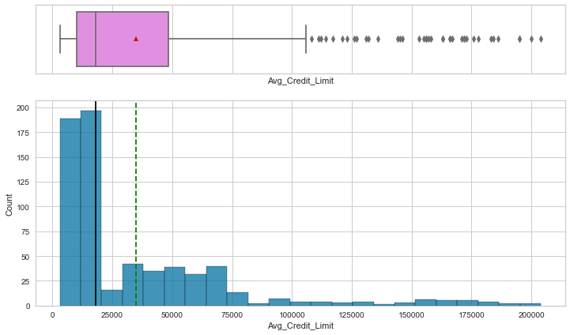

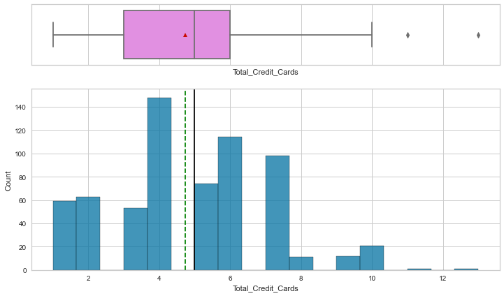

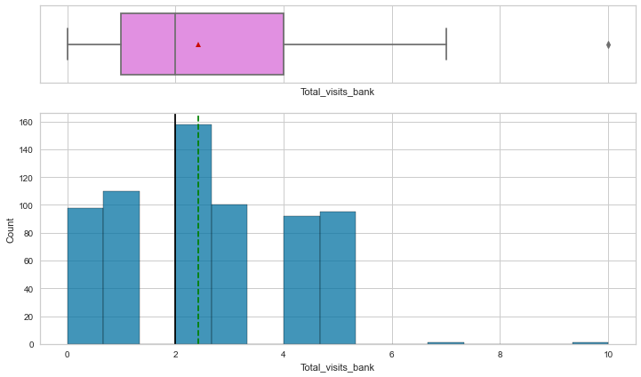

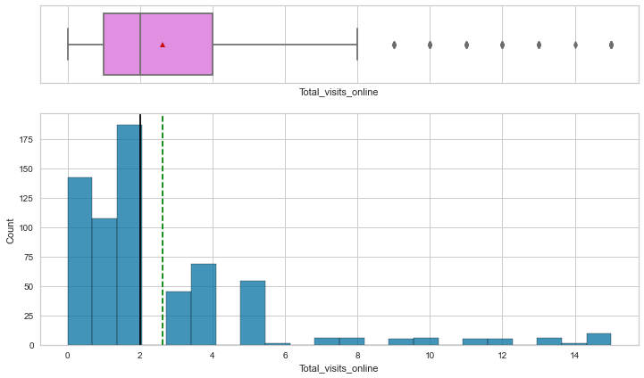

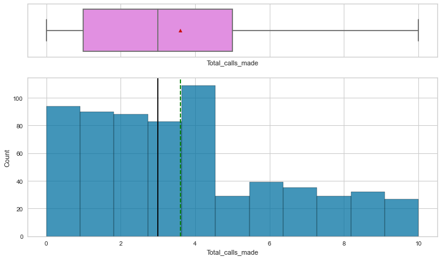

```python
# Let's see the plots on numerical columns
num_col = df2.select_dtypes(['int64','float64']).columns
for col in num_col:
    histogram_boxplot(df2, col)
```

## Observations

- `Avg_Credit_Limit` - skewed and has a lots of outliers.
- `Total_Credit_Cards` - only a couple of outliers.
- `Total_visits_bank` - just one outlier.
- `Total_visits_online` - skewed and has a lots of outliers.
- `Total_calls_made` - a little skewed but no outliers.

```python
# Let's do a log to decrease the skew on the ones which are highly skewed. The +1 is to handle the log error with 0s.
df2["Avg_Credit_Limit"] = np.log(df2["Avg_Credit_Limit"])
df2["Total_visits_online"] = np.log(df2["Total_visits_online"]+1)
```

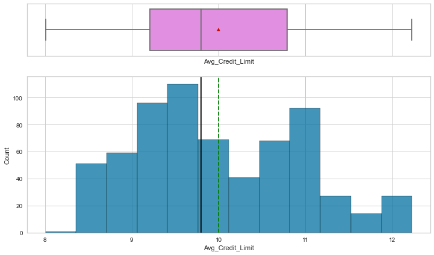

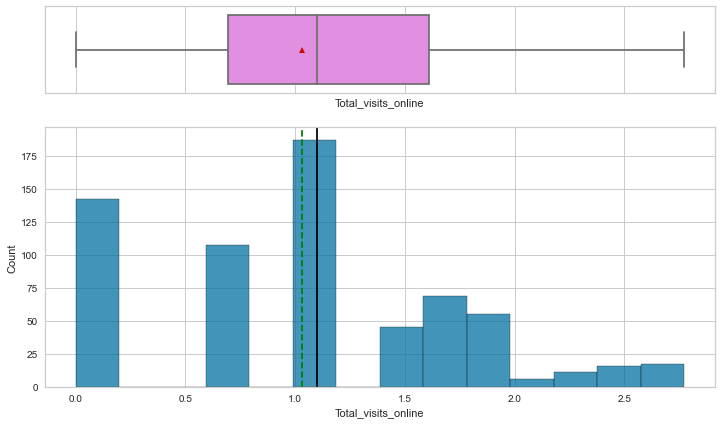

```python
# Let's see how the skew looks now.
histogram_boxplot(df2, "Avg_Credit_Limit")
histogram_boxplot(df2, "Total_visits_online")
```

- Both the skewness and the outliers are handled.
- Let's handle the ouerliers before continuing EDA. Not all modeling algorithms are sensitive to outliers. However, it's safer to do so.

## Outlier treatment

```python
# Based on the boxplots earlier, a few attributes could do with some outlier fixes. We will cap any high outlier value to Q3+(1.5*IQR

cols = ['Total_Credit_Cards', 'Total_visits_bank']
for col in cols:
    Q1 = df2[col].quantile(0.25)
    Q3 = df2[col].quantile(0.75)
    IQR = Q3 - Q1
    df2[col] = np.where(df2[col] > (Q3+(1.5*IQR)),(Q3+(1.5*IQR)),df2[col])
```

```python
# Now's let's see the distribution again.
df2.describe().T
```

|  | count | mean | std | min | 25% | 50% | 75% | max |
| --- | --- | --- | --- | --- | --- | --- | --- | --- |
| Avg_Credit_Limit | 655.0 | 10.000241 | 0.934820 | 8.006368 | 9.210340 | 9.798127 | 10.789266 | 12.225875 |
| Total_Credit_Cards | 655.0 | 4.737405 | 2.214883 | 1.000000 | 3.000000 | 5.000000 | 6.000000 | 10.500000 |
| Total_visits_bank | 655.0 | 2.419084 | 1.648469 | 0.000000 | 1.000000 | 2.000000 | 4.000000 | 8.500000 |
| Total_visits_online | 655.0 | 1.030260 | 0.710246 | 0.000000 | 0.693147 | 1.098612 | 1.609438 | 2.772589 |
| Total_calls_made | 655.0 | 3.610687 | 2.869678 | 0.000000 | 1.000000 | 3.000000 | 5.000000 | 10.000000 |

## Bivariate Analysis

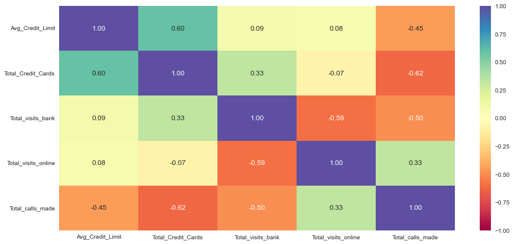

```python
plt.figure(figsize=(15, 7))
sns.heatmap(df2.corr(), annot=True, vmin=-1, vmax=1, fmt=".2f", cmap="Spectral")
plt.show()
```

## Observations

- `Avg_Credit_Limit:` - Positively correlated with Total_Credit_Cards. Negatively correlated with Total_calls_made.
- `Total_Credit_Cards:` - (Weakly) positively correlated with Total_visits_bank. Negatively correlated with Total_calls_made.
- `Total_visits_bank:` - Negatively correlated with Total_calls_made and Total_visits_online.
- `Total_visits_online:` - (Weakly) positively correlated with Total_calls_made
- Altough there are correlations, it's not high enough (> 0.9) to warrant dropping of any feature.

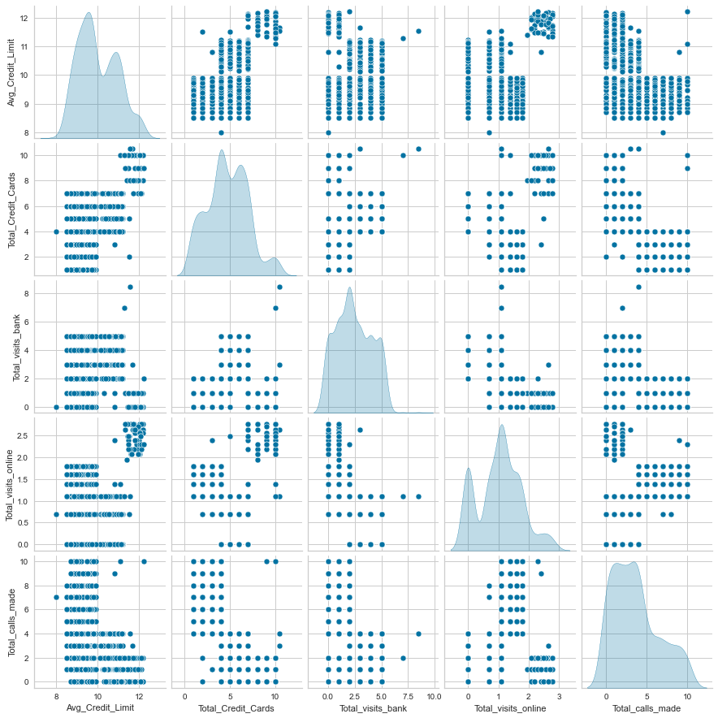

```python
sns.pairplot(data=df2, diag_kind="kde")
plt.show()
```

- Multiple peaks could indicate the different clusters (or segments) of customers. We will explore this more in the next segments of this notebook.

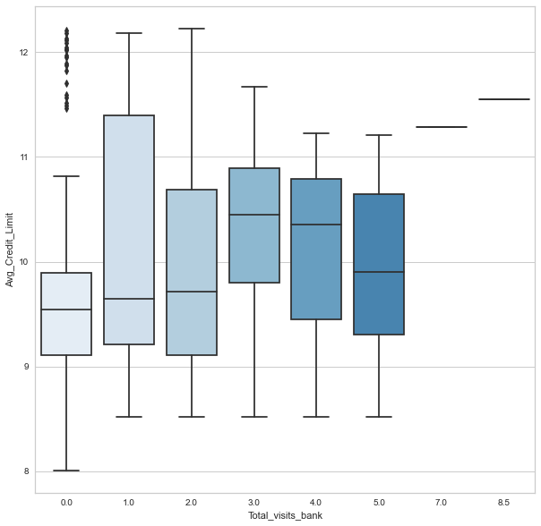

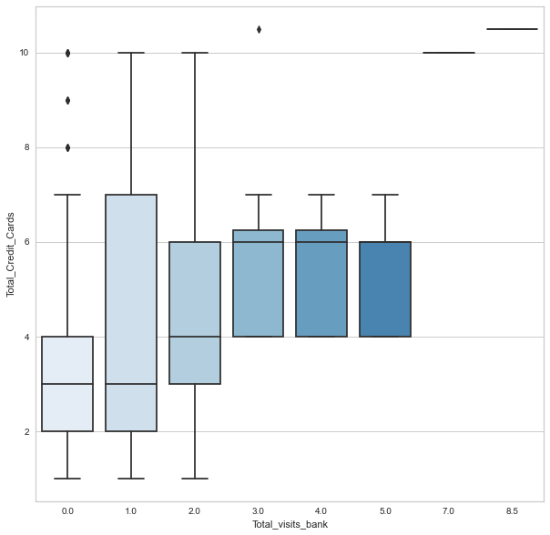

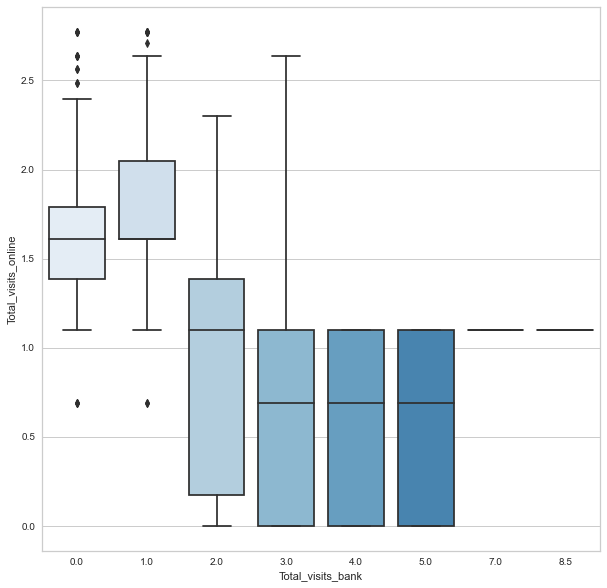

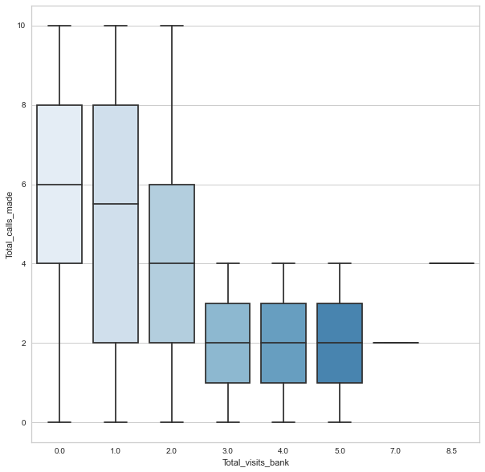

```python
# Let's continue the bivariate analysis with box plots

cols = ['Avg_Credit_Limit','Total_Credit_Cards'	,'Total_visits_online','Total_calls_made']
target_col = 'Total_visits_bank'

for col1 in cols:
    plt.figure(figsize=(10, 10))
    plt.legend(labels=[col1])
    sns.boxplot(data=df2, x=target_col, y=df2[col1], palette="Blues");
    plt.show()
```

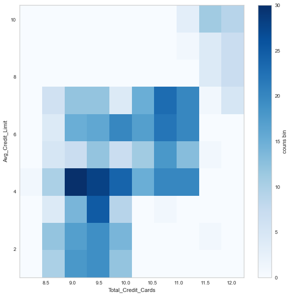

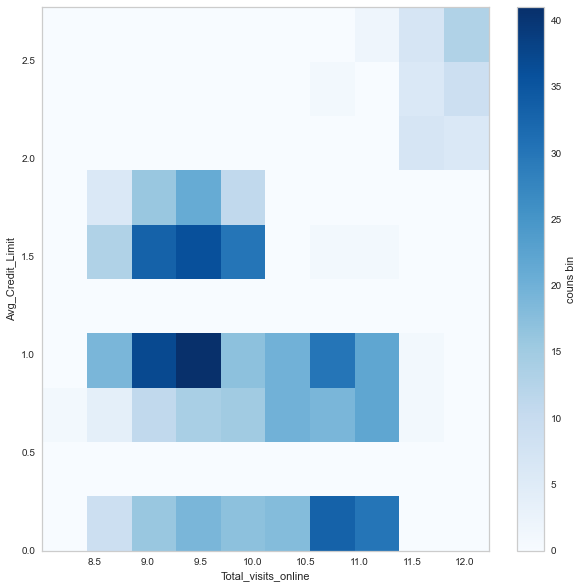

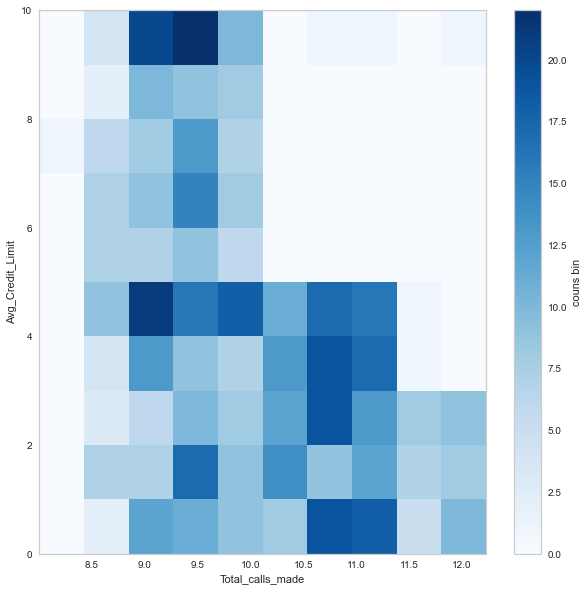

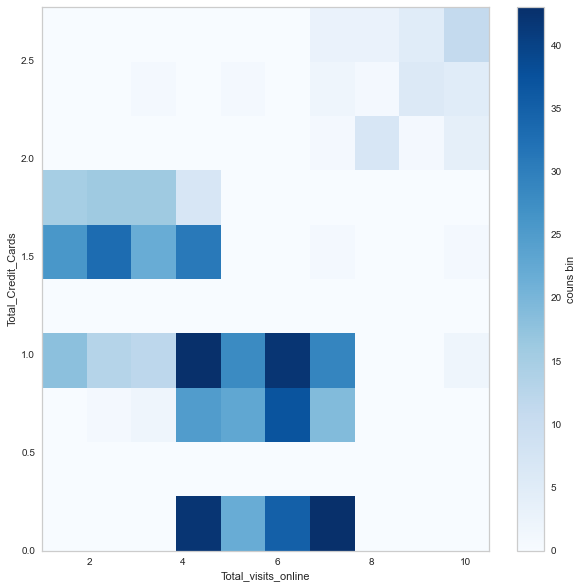

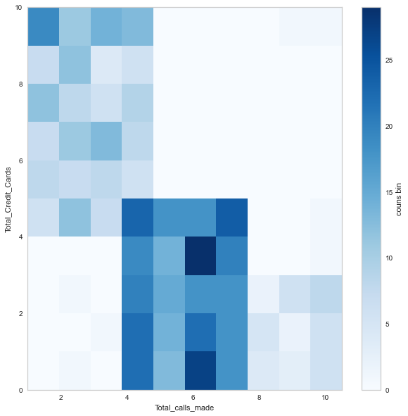

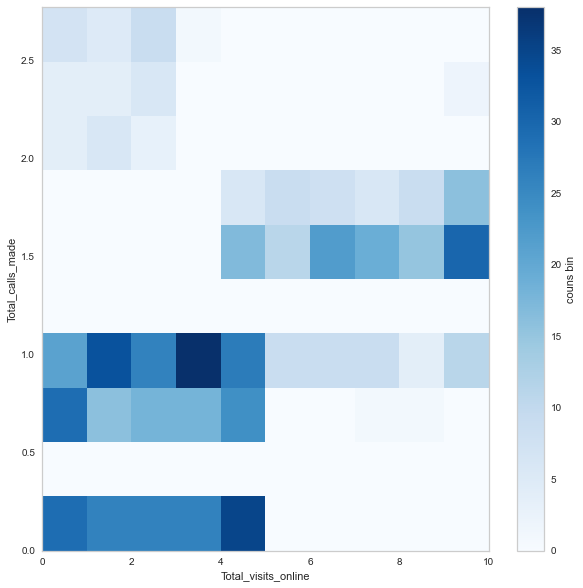

```python
# 2D histograms show a sort of a heatmap where the most frequent combinations occur.
cols = ['Avg_Credit_Limit','Total_Credit_Cards'	,'Total_visits_online','Total_calls_made']
for col1 in cols:
    for col2 in cols:
        if(col1<col2):
            plt.figure(figsize=(10, 10))
            plt.hist2d(df2[col1], df2[col2], cmap='Blues')
            cb = plt.colorbar()
            cb.set_label("couns bin")
            plt.xlabel(col2)
            plt.ylabel(col1)
            plt.show()
```

- This visualization shows possible clusters taking two attributes at at time.
- For example, Total_calls_made vs Total_visits_online above hints at three clusters.
- Since we will be doing k-means clustering later, we will hold on to the comments on this for now.

## Observations

- Those who have higher bank visits tend to have a lower telephone calls.
- Those who have higher bank visits tend to have a online interactions.
- Those who have higher bank visits tend to have a higher number of credit cards.
- The attributes seem to be multi modal in nature. Hence, clustering can be expected to tease out the different customer segments.

```python
# Scaling before modeling
scaled_df_z = df2.apply(zscore)
```

```python
scaled_df_z.head()
```

| Customer Key | Avg_Credit_Limit | Total_Credit_Cards | Total_visits_bank | Total_visits_online | Total_calls_made |
| --- | --- | --- | --- | --- | --- |
| 11265 | 0.898548 | 1.022322 | 0.352667 | 0.096311 | -1.259182 |
| 11398 | -0.650439 | 0.570486 | 1.566841 | 0.096311 | -0.910444 |
| 11412 | -0.158491 | -1.236858 | -0.254421 | 0.501666 | 0.135768 |
| 11466 | -0.958415 | 1.022322 | 1.566841 | -1.451678 | -1.259182 |
| 11562 | 0.583552 | -0.333186 | 0.352667 | 0.096311 | -1.259182 |

### K-means clustering

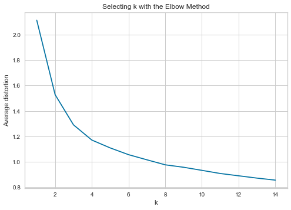

```python
#Finding optimal no. of clusters

clusters=range(1,15)
meanDistortions=[]

for k in clusters:
    model=KMeans(n_clusters=k, random_state=1)
    model.fit(scaled_df_z)
    prediction=model.predict(scaled_df_z)
    meanDistortions.append(sum(np.min(cdist(scaled_df_z, model.cluster_centers_, 'euclidean'), axis=1)) / scaled_df_z.shape[0])


plt.plot(clusters, meanDistortions, 'bx-')
plt.xlabel('k')
plt.ylabel('Average distortion')
plt.title('Selecting k with the Elbow Method')
```

- Based on the elbow method, k=3 seems the best value for the number of clusters.

```
For n_clusters = 2, the silhouette score is 0.4106367018713233)
For n_clusters = 3, the silhouette score is 0.4793870125329323)
For n_clusters = 4, the silhouette score is 0.372645743800702)
For n_clusters = 5, the silhouette score is 0.3518609608177535)
For n_clusters = 6, the silhouette score is 0.2516863980193908)
For n_clusters = 7, the silhouette score is 0.2518681866970513)
For n_clusters = 8, the silhouette score is 0.25437729202082204)
For n_clusters = 9, the silhouette score is 0.23749560928214775)
For n_clusters = 10, the silhouette score is 0.2462316437008115)
For n_clusters = 11, the silhouette score is 0.24815180219244362)
For n_clusters = 12, the silhouette score is 0.2399428018929787)
For n_clusters = 13, the silhouette score is 0.23566957722466703)
For n_clusters = 14, the silhouette score is 0.2314714693580614)
```

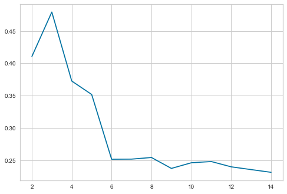

```python
sil_score = []
cluster_list = list(range(2, 15))
for n_clusters in cluster_list:
    clusterer = KMeans(n_clusters=n_clusters, random_state=1)
    preds = clusterer.fit_predict((scaled_df_z))
    # centers = clusterer.cluster_centers_
    score = silhouette_score(scaled_df_z, preds)
    sil_score.append(score)
    print("For n_clusters = {}, the silhouette score is {})".format(n_clusters, score))

plt.plot(cluster_list, sil_score)
plt.show()
```

- k=3 has the best silhouette score. This is consistent with the conclusion drawn from the elbow method.

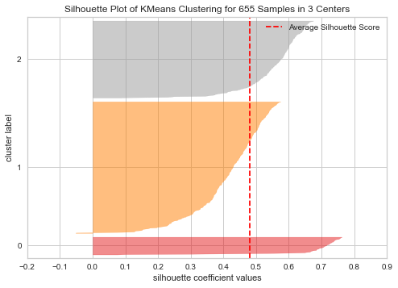

```python
# finding optimal no. of clusters with silhouette coefficients
visualizer = SilhouetteVisualizer(KMeans(3, random_state=1))
visualizer.fit(scaled_df_z)
visualizer.show()
```

```python
# let's take 4 as number of clusters
kmeans = KMeans(n_clusters=3, random_state=1)
kmeans.fit(scaled_df_z)
# adding kmeans cluster labels to the original and scaled dataframes

scaled_df_z["K_means_segments"] = kmeans.labels_
df2["K_means_segments"] = kmeans.labels_
cluster_profile = df2.groupby("K_means_segments").mean()
cluster_profile["count_in_each_segments"] = (
    df2.groupby("K_means_segments")["Avg_Credit_Limit"].count().values
)
# let's display cluster profiles
cluster_profile.style.highlight_max(color="lightgreen", axis=0)
```

| K_means_segments | Avg_Credit_Limit | Total_Credit_Cards | Total_visits_bank | Total_visits_online | Total_calls_made | count_in_each_segments |
| --- | --- | --- | --- | --- | --- | --- |
| 0 | 11.796569 | 8.855769 | 0.711538 | 2.411509 | 1.500000 | 52 |
| 1 | 10.155416 | 5.535526 | 3.519737 | 0.577109 | 2.005263 | 380 |
| 2 | 9.316945 | 2.417040 | 0.941704 | 1.480362 | 6.838565 | 223 |

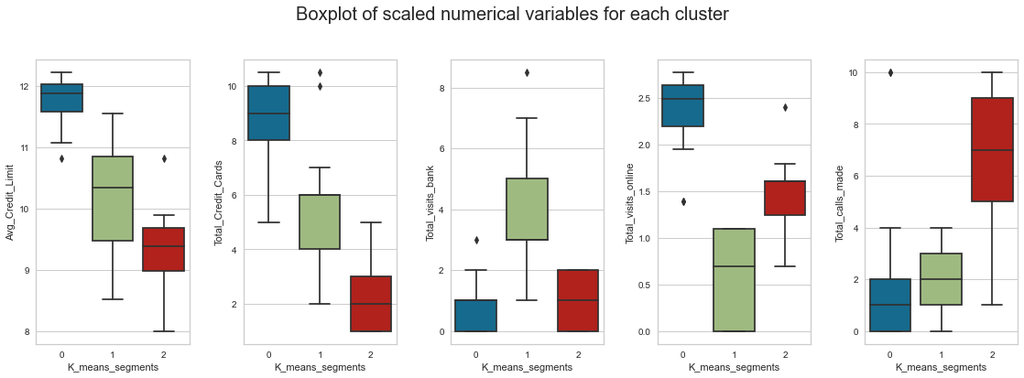

```python
fig, axes = plt.subplots(1, 5, figsize=(16, 6))
fig.suptitle("Boxplot of scaled numerical variables for each cluster", fontsize=20)
counter = 0
for ii in range(5):
    sns.boxplot(
        ax=axes[ii],
        y=df2[num_col[counter]],
        x=df2["K_means_segments"],
    )
    counter = counter + 1

fig.tight_layout(pad=2.0)
```

### Hierarchical clustering

```python
# Now let's create a dataset for the hierchahical clustering

df3=df2[['Avg_Credit_Limit','Total_Credit_Cards'	,'Total_visits_online','Total_calls_made','Total_visits_bank']]
df3.head()
```

| Customer Key | Avg_Credit_Limit | Total_Credit_Cards | Total_visits_online | Total_calls_made | Total_visits_bank |
| --- | --- | --- | --- | --- | --- |
| 11265 | 10.839581 | 7.0 | 1.098612 | 0 | 3.0 |
| 11398 | 9.392662 | 6.0 | 1.098612 | 1 | 5.0 |
| 11412 | 9.852194 | 2.0 | 1.386294 | 4 | 2.0 |
| 11466 | 9.104980 | 7.0 | 0.000000 | 0 | 5.0 |
| 11562 | 10.545341 | 4.0 | 1.098612 | 0 | 3.0 |

```python
# list of distance metrics
distance_metrics = ["euclidean", "chebyshev", "mahalanobis", "cityblock"]

# The Mahalanobis distance is a measure of the distance between a point P and a distribution D.
# It is a multi-dimensional generalization of the idea of measuring how many standard deviations away P is from the mean of D.

# Cityblock distance is the L1 distance, or Manhattan distance.
# list of linkage methods
linkage_methods = ["single", "complete", "average", "weighted","ward","centroid"]

high_cophenet_corr = 0
high_dm_lm = [0, 0]

for dm in distance_metrics:
    print(" ")
    for lm in linkage_methods:
        if(lm == "ward" or lm == "centroid"):
            dm="euclidean"
        Z = linkage(df3, metric=dm, method=lm) # Perform hierarchical/agglomerative clustering.
        c, coph_dists = cophenet(Z, pdist(df3)) # Calculate the cophenetic distances between each observation
        # in the hierarchical clustering defined by the linkage Z.

        # Returns: The cophentic correlation distance and
        # The cophenetic distance matrix in condensed form.
        print(
            "Cophenetic correlation for {} distance and {} linkage is {}.".format(
                dm.capitalize(), lm, c
            )
        )
        if high_cophenet_corr < c:
            high_cophenet_corr = c
            high_dm_lm[0] = dm
            high_dm_lm[1] = lm
```

```
Cophenetic correlation for Euclidean distance and single linkage is 0.3578951285096909.
Cophenetic correlation for Euclidean distance and complete linkage is 0.7923018237860767.
Cophenetic correlation for Euclidean distance and average linkage is 0.7968536612469018.
Cophenetic correlation for Euclidean distance and weighted linkage is 0.7912192585981501.
Cophenetic correlation for Euclidean distance and ward linkage is 0.7603285844974335.
Cophenetic correlation for Euclidean distance and centroid linkage is 0.7878703922127959.

Cophenetic correlation for Chebyshev distance and single linkage is 0.16318011546172634.
Cophenetic correlation for Chebyshev distance and complete linkage is 0.7671735578909324.
Cophenetic correlation for Chebyshev distance and average linkage is 0.7973391606029665.
Cophenetic correlation for Chebyshev distance and weighted linkage is 0.7950416275015407.
Cophenetic correlation for Euclidean distance and ward linkage is 0.7603285844974335.
Cophenetic correlation for Euclidean distance and centroid linkage is 0.7878703922127959.

Cophenetic correlation for Mahalanobis distance and single linkage is 0.3232836560348102.
Cophenetic correlation for Mahalanobis distance and complete linkage is 0.2870790665687664.
Cophenetic correlation for Mahalanobis distance and average linkage is 0.5451758873525804.
Cophenetic correlation for Mahalanobis distance and weighted linkage is 0.5147321988350608.
Cophenetic correlation for Euclidean distance and ward linkage is 0.7603285844974335.
Cophenetic correlation for Euclidean distance and centroid linkage is 0.7878703922127959.

Cophenetic correlation for Cityblock distance and single linkage is 0.4367747964459988.
Cophenetic correlation for Cityblock distance and complete linkage is 0.7853390150007595.
Cophenetic correlation for Cityblock distance and average linkage is 0.7867134852475334.
Cophenetic correlation for Cityblock distance and weighted linkage is 0.7882023502229569.
Cophenetic correlation for Euclidean distance and ward linkage is 0.7603285844974335.
Cophenetic correlation for Euclidean distance and centroid linkage is 0.7878703922127959.
```

```python
# printing the combination of distance metric and linkage method with the highest cophenetic correlation
print(
    "Highest cophenetic correlation is {}, which is obtained with {} distance and {} linkage.".format(
        high_cophenet_corr, high_dm_lm[0].capitalize(), high_dm_lm[1]
    )
)
```

```
Highest cophenetic correlation is 0.7973391606029665, which is obtained with Chebyshev distance and average linkage.
```

**We see that the cophenetic correlation is maximum with Chebyshev distance and average linkage.**

**Let's see the dendrograms for the different linkage methods.**

- We are going with euclidian here because it works with all linkage methods and is intuitive to understand. And in this case, it was very close to Chebyshev distance.

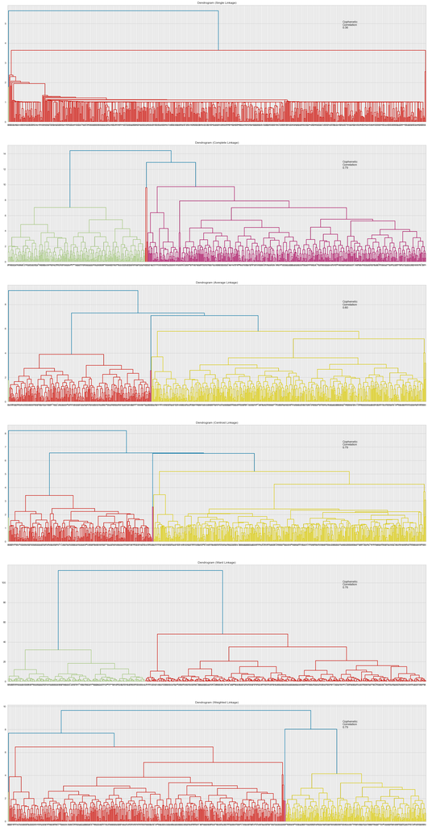

```python
# list of linkage methods
linkage_methods = ["single", "complete", "average", "centroid", "ward", "weighted"]

# lists to save results of cophenetic correlation calculation
compare_cols = ["Linkage", "Cophenetic Coefficient"]

# to create a subplot image
fig, axs = plt.subplots(len(linkage_methods), 1, figsize=(30, 60))

# We will enumerate through the list of linkage methods above
# For each linkage method, we will plot the dendrogram and calculate the cophenetic correlation
for i, method in enumerate(linkage_methods):
    Z = linkage(df3, metric="euclidean", method=method)

    dendrogram(Z, ax=axs[i])
    axs[i].set_title(f"Dendrogram ({method.capitalize()} Linkage)")

    coph_corr, coph_dist = cophenet(Z, pdist(df3))
    axs[i].annotate(
        f"Cophenetic\nCorrelation\n{coph_corr:0.2f}",
        (0.80, 0.80),
        xycoords="axes fraction",
    )
```

**Observations**

- The cophenetic correlation is highest for average.
- We will move ahead with average linkage.
- 6 appears to be the appropriate number of clusters from the dendrogram for average linkage. This process is subjective and usually needs some domain experience as well.

```python
HCmodel = AgglomerativeClustering(n_clusters=6, affinity="euclidean", linkage="average")
HCmodel.fit(df3)
```

```
AgglomerativeClustering(linkage='average', n_clusters=6)
```

```python
df3["HC_Clusters"] = HCmodel.labels_
```

## Cluster Profiling

```python
cluster_profile = df3.groupby("HC_Clusters").mean()
```

```python
cluster_profile["count_in_each_segments"] = (
    df3.groupby("HC_Clusters")["Avg_Credit_Limit"].count().values
)
cluster_profile["count_in_each_segments"]
```

```
HC_Clusters
0      4
1     48
2    221
3      2
4      2
5    378
Name: count_in_each_segments, dtype: int64
```

- Though we specified 6 clusters, 3 of them are too small. So effectively, there are 3 clusters. This is the same result as k-means clustering.

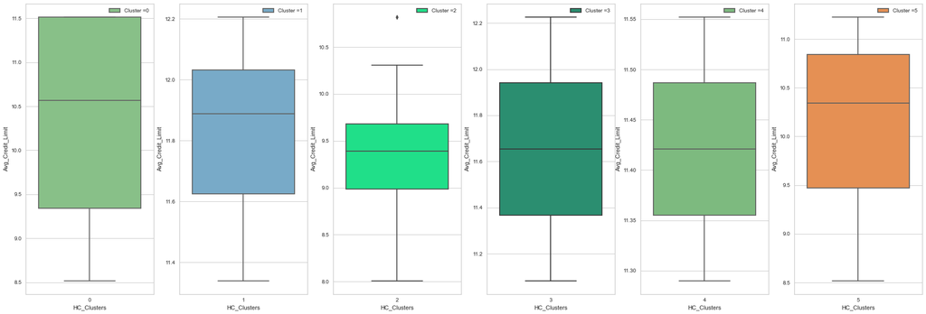

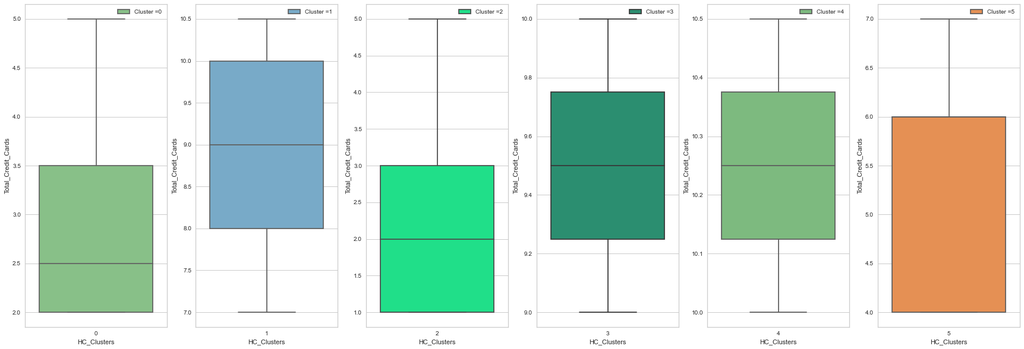

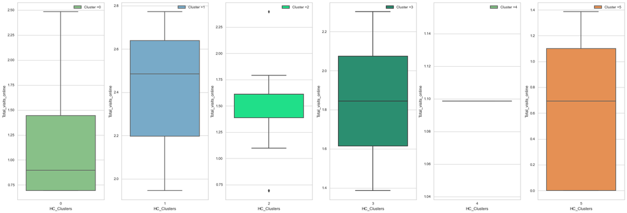

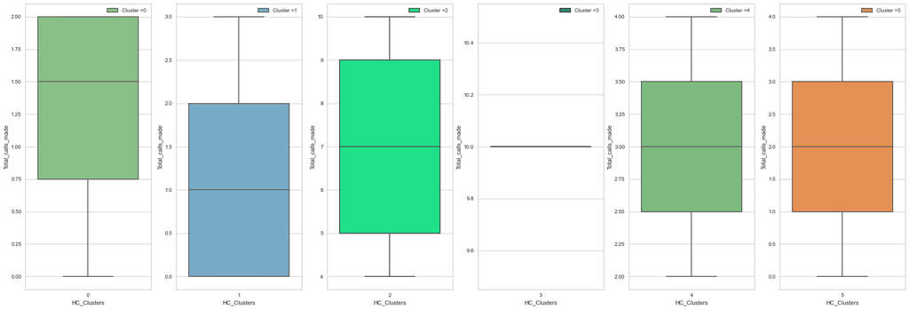

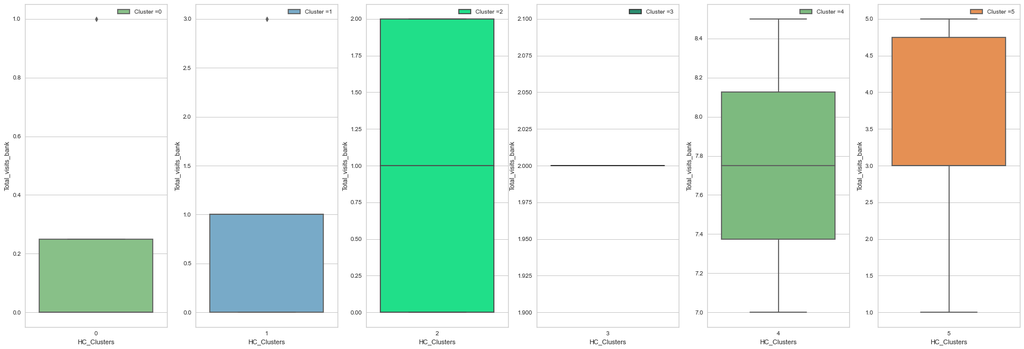

```python
# Let's look at boxplots and histograms of the numeric attributes splitting it on based on clusters

cols = ['Avg_Credit_Limit','Total_Credit_Cards'	,'Total_visits_online','Total_calls_made','Total_visits_bank']
#cols = ['Avg_Credit_Limit']
numclusters = 6

for col in cols:
        plt.figure(figsize=(30, 10))
        mycluster=0
        plt.subplot(1, 6, mycluster+1)
        sns.boxplot(data=df3[df3["HC_Clusters"]==mycluster], x="HC_Clusters", y=df3[col], palette="Accent");
        plt.legend(labels=["Cluster ="+str(mycluster)])
        mycluster=1
        plt.subplot(1, 6, mycluster+1)
        sns.boxplot(data=df3[df3["HC_Clusters"]==mycluster], x="HC_Clusters", y=df3[col], palette="Blues");
        plt.legend(labels=["Cluster ="+str(mycluster)])
        mycluster=2
        plt.subplot(1, 6, mycluster+1)
        sns.boxplot(data=df3[df3["HC_Clusters"]==mycluster], x="HC_Clusters", y=df3[col], palette="gist_rainbow");
        plt.legend(labels=["Cluster ="+str(mycluster)])
        mycluster=3
        plt.subplot(1, 6, mycluster+1)
        sns.boxplot(data=df3[df3["HC_Clusters"]==mycluster], x="HC_Clusters", y=df3[col], palette="Dark2");
        plt.legend(labels=["Cluster ="+str(mycluster)])
        mycluster=4
        plt.subplot(1, 6, mycluster+1)
        sns.boxplot(data=df3[df3["HC_Clusters"]==mycluster], x="HC_Clusters", y=df3[col], palette="Greens");
        plt.legend(labels=["Cluster ="+str(mycluster)])
        mycluster=5
        plt.subplot(1, 6, mycluster+1)
        sns.boxplot(data=df3[df3["HC_Clusters"]==mycluster], x="HC_Clusters", y=df3[col], palette="Oranges");
        plt.legend(labels=["Cluster ="+str(mycluster)])
        plt.show()
```

```python
# lets display cluster profile
# Highlight the max value for each attribute
cluster_profile.style.highlight_max(color="lightgreen", axis=0)
```

| HC_Clusters | Avg_Credit_Limit | Total_Credit_Cards | Total_visits_online | Total_calls_made | Total_visits_bank | count_in_each_segments |
| --- | --- | --- | --- | --- | --- | --- |
| 0 | 10.289712 | 3.000000 | 1.242453 | 1.250000 | 0.250000 | 4 |
| 1 | 11.828768 | 8.947917 | 2.454966 | 1.083333 | 0.666667 | 48 |
| 2 | 9.325796 | 2.416290 | 1.483817 | 6.886878 | 0.945701 | 221 |
| 3 | 11.654009 | 9.500000 | 1.844440 | 10.000000 | 2.000000 | 2 |
| 4 | 11.420964 | 10.250000 | 1.098612 | 3.000000 | 7.750000 | 2 |
| 5 | 10.143036 | 5.523810 | 0.577256 | 2.010582 | 3.500000 | 378 |

```python
# Highlight the min value for each attribute
cluster_profile.style.highlight_min(color="yellow", axis=0)
```

| HC_Clusters | Avg_Credit_Limit | Total_Credit_Cards | Total_visits_online | Total_calls_made | Total_visits_bank | count_in_each_segments |
| --- | --- | --- | --- | --- | --- | --- |
| 0 | 10.289712 | 3.000000 | 1.242453 | 1.250000 | 0.250000 | 4 |
| 1 | 11.828768 | 8.947917 | 2.454966 | 1.083333 | 0.666667 | 48 |
| 2 | 9.325796 | 2.416290 | 1.483817 | 6.886878 | 0.945701 | 221 |
| 3 | 11.654009 | 9.500000 | 1.844440 | 10.000000 | 2.000000 | 2 |
| 4 | 11.420964 | 10.250000 | 1.098612 | 3.000000 | 7.750000 | 2 |
| 5 | 10.143036 | 5.523810 | 0.577256 | 2.010582 | 3.500000 | 378 |

## K-means vs Hierarchical Clustering

- k-means suggested three clusters whereas hierarchical clustering suggested six.
- However, three of those six were very small and can practically be ignored as outliers.
- So for all practical purposes, both methods have suggested three clusters.
- Two of the those three are same in k-means vs hirarchical (not same among themselves).
- Time it takes to do Hierarchical Clustering is much more than what it takes to do k-means clustering
- Both can be interpreted easily, although Hierarchical clustering is easier to visualize if there are not too many data points. K-means is easier to visualize for humans if there are 1 or 2 variables.

### PCA

- Although with just 5 variables, PCA is not strictly needed. But since we observed a few correlations earlier, it would be interesting to check what PCA shows.

```python
df4 = df3[['Avg_Credit_Limit','Total_Credit_Cards'	,'Total_visits_online','Total_calls_made','Total_visits_bank']]
df4.head()
```

| Customer Key | Avg_Credit_Limit | Total_Credit_Cards | Total_visits_online | Total_calls_made | Total_visits_bank |
| --- | --- | --- | --- | --- | --- |
| 11265 | 10.839581 | 7.0 | 1.098612 | 0 | 3.0 |
| 11398 | 9.392662 | 6.0 | 1.098612 | 1 | 5.0 |
| 11412 | 9.852194 | 2.0 | 1.386294 | 4 | 2.0 |
| 11466 | 9.104980 | 7.0 | 0.000000 | 0 | 5.0 |
| 11562 | 10.545341 | 4.0 | 1.098612 | 0 | 3.0 |

```python
pca = PCA(n_components=5)
pca.fit(df4)
```

```
PCA(n_components=5)
```

```python
print(pca.explained_variance_) # Eigen values
```

```
[11.91969897  2.69766631  1.84273725  0.49326506  0.28318167]
```

```python
print(pca.explained_variance_ratio_) # % of variance explained by each eigen vector
```

```
[0.69153627 0.15650849 0.10690871 0.02861739 0.01642914]
```

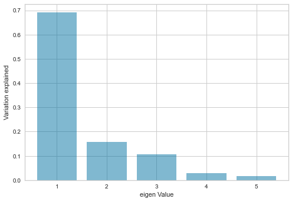

```python
# The above data visualized
plt.bar(list(range(1,6)),pca.explained_variance_ratio_,alpha=0.5, align='center')
plt.ylabel('Variation explained')
plt.xlabel('eigen Value')
plt.show()
```

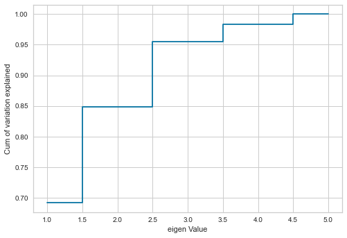

```python
# The above data visualized as a cumulative plot
plt.step(list(range(1,6)),np.cumsum(pca.explained_variance_ratio_), where='mid')
plt.ylabel('Cum of variation explained')
plt.xlabel('eigen Value')
plt.show()
```

```python
# setting the number of components to 2
pca = PCA(n_components=2)

# transforming data and storing results in a dataframe
X_reduced_pca = pca.fit_transform(df4)
reduced_df_pca = pd.DataFrame(
    data=X_reduced_pca, columns=["Component 1", "Component 2"]
)
```

```python
# checking the amount of variance explained
pca.explained_variance_ratio_.sum()
```

```
0.8480447601501165
```

- The first two principal components explain 84.8% of the variance in the data.

```python
reduced_df_pca.head()
```

|  | Component 1 | Component 2 |
| --- | --- | --- |
| 0 | -4.313708 | 0.413742 |
| 1 | -3.346459 | -1.395018 |
| 2 | 1.891776 | -1.577136 |
| 3 | -4.689984 | -1.314813 |
| 4 | -2.713224 | -1.810816 |

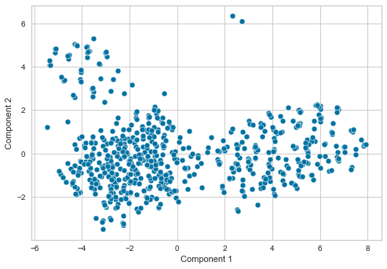

```python
sns.scatterplot(data=reduced_df_pca, x="Component 1", y="Component 2");
```

- We can kind of see the broad clusters.
- If we draw a vertical line around x=1, another horizantal line at y=2, we can partition the points into the clusters.
- There a few outlier points too.

### Conclusion

- EDA was performed and observations were made based on univariate and multivariate analysis.
- Outliers were handled. There were no missing values to be taken care of, but duplicates were handled.
- Feature engineering was done to reduce skew and outliers.
- The attributes were found to be multi modal in nature. Hence, clustering could be expected to tease out the different customer segments.
- K-means clustering was done and model performance was studied systematically w.r.t the number of clusters,
- This was followed by hierarchical clustering and dendograms were studied. The model results were investigated and compared with the k-means results.
- Individual clusters were studied and characterized to glean business insights.